Renata Camarena  
625784

# Análisis de factores asociados al consumo excesivo de alcohol por entidad federativa en México

## Introducción

El consumo excesivo de alcohol es un problema relevante de salud pública en México. De acuerdo con la ENSANUT Continua 2023, el 41.9% de los adultos de 20 años o más reportó consumo excesivo de alcohol durante el último año, esta cifra representa alrededor de 36 millones de personas. Además, el 19.3% reportó consumo excesivo durante los 30 días antes de la encuesta. Sin embargo, también cabe destacar que estos números varían de distintas maneras en los 32 estados de la república mexicana.

Ante la magnitud de esta problemática, es importante analizar las características demográficas y de salud de la población que podrían estar asociadas con el consumo excesivo de alcohol. En este proyecto se estudiará su relación con la prevalencia de tabaquismo, la estructura de edad de la piblación, la prevalencia de sobrepeso u obesidad y la prevalencia de enfermedades en el país.

El objetivo no es establecer que las variables previamente mencionadas sean causas directas del consumo excesivo de alcohol, sino determinar en qué medida su comportamiento permite expicar las diferencias observadas entre los estados de México.

A partir de este problema, se plantea la siguiente pregunta de investigación: ¿En qué medida la prevalencia de tabaquismo, la estructura de edad de la población, la prevalencia de sobrepeso u obesidad y la prevalencia de enfermos permiten explicar las diferencias estatales en el consumo excesivo de alcohol en México?

La variable respuesta del estudio será la prevalencia de consumo excesivo de alcohol, mientras que la prevalencia de tabaquismo, la estructura de edad, la prevalencia de enfermedades y la prevalencia de sobrepeso u obesidad serán inicialmente consideradas como posibles variables explicativas. Asimismo, debido a que la variable de interés es cuantitativa y se busca analizar su relación con distintas características, se utilizarán modelos de regresión.

Este análisis permitirá evaluar la capacidad de estas variables para predecir las diferencias estatales en el consumo excesivo de alcohol y estudiarlas, usando inferencia estadística, para saber cuáles de ellas presentan una asociación significativa con la respuesta. Para lograr esto, se compararán modelos de regresión lineales y no lineales, tomando en consideración su desempeño predictivio y la interpretación de las relaciones encontradas.

## Descripción de los datos y fuentes de información

Para realizar este análisis se integró información proveniente de fuentes públicas y oficiales del gobierno de México. Las variables relacionadas con salud y hábitos de la población (tabaquismo, sobrepeso u obesidad y consumo excesivo de alcohol) fueron obtenidas principalmente de la Encuesta Nacional de Salud y Nutrición (ENSANUT), elaborada por el Instituto Nacional de Salud Pública. Esta encuesta tiene como objetivo actualizar información sobre las condiciones de salud y nutrición de la población de México y generar estimaciones para las 32 entidades federativas.

Para representar la estructura de edad de la población se utilizaron datos del Instituto Nacional de Estadpistica y Geografía (INEGI), esoecíficamente información de población por entidad federativa y grupos de edad. El INEGI tiene información por grupos quinquenales y entidad federativa, lo que permite calcular indicadores relacionados con la composición de edad de cada estado.

Adicionalmente, se consultó información del Anuario de Morbilidad de la Dirección General de Epidemiología de la Secretaría de Salud, donde se concentran registros de morbilidad por entidad federativa y permite incorporar información relacionada con la presencia de enfermedades en la población mexicana.

Después de integrar y procesar las diferentes fuentes de información, se construyó una base de datos en la que cada observaión representa una entidad federativa de México. Las variables utilizadas en el análisis son:

1. PrevalenciaAlcoholExcesivo: Variable de respuesta.
2. PrevalenciaFumadores: Variable explicativa.
3. PrevalenciaPersonasEdad18: Variable explicativa (indicador relacionado con la estructura de edad de la población que puede consumir alcohol de manera legal).
4. PrevalenciaSobrepesoObesidad: Variable explicativa.
5. PrevalenciaEnfermos: Variable explicativa.

## Exploración y comprensión del conjunto de datos

El conjunto de datos utilizado está compuesto por 32 observaciones, correspondientes a los 32 estados de México y 6 variables. Una de ellas identifica al estado, por lo que es de tipo cualitativa, mientras que las cinco variables restantes son variables cuantitativas expresadas como prevalencias.

La Tabla 1 presenta una vista general de la base de datos y permite observar las diferencias existentes entre las entidades federativas para cada una de las variables consideradas. Los valores de prevalencia se encuentras expresados de manera decimal para representar un porcentaje.

```python
data = pd.read_csv("basededatosfinal.csv")
(data.head(32).style.hide(axis="index").set_properties(**{'text-align': 'center'}).set_table_styles([{'selector': 'th', 'props': [('text-align', 'center')]}]).set_caption("[TABLA 1]. Vista previa del conjunto de datos."))
```

[TABLA 1]. Vista previa del conjunto de datos.

| Entidad | PrevalenciaEnfermos | PrevalenciaPersonasEdad18 | PrevalenciaFumadores | PrevalenciaSobrepesoObesidad | PrevalenciaAlcoholExcesivo |
| --- | --- | --- | --- | --- | --- |
| Aguascalientes | 0.315240 | 0.636176 | 0.215000 | 0.725000 | 0.447000 |
| Baja California | 0.231026 | 0.681041 | 0.233000 | 0.794000 | 0.439000 |
| Baja California Sur | 0.385457 | 0.666397 | 0.205000 | 0.818000 | 0.430000 |
| Campeche | 0.326735 | 0.653635 | 0.176000 | 0.824000 | 0.298000 |
| Chiapas | 0.223794 | 0.580705 | 0.114000 | 0.712000 | 0.244000 |
| Chihuahua | 0.302119 | 0.658915 | 0.225000 | 0.728000 | 0.408000 |
| Ciudad de México | 0.303870 | 0.748881 | 0.214000 | 0.748000 | 0.378000 |
| Coahuila | 0.307408 | 0.650523 | 0.218000 | 0.789000 | 0.389000 |
| Colima | 0.387257 | 0.677625 | 0.155000 | 0.746000 | 0.343000 |
| Durango | 0.300439 | 0.628915 | 0.178000 | 0.778000 | 0.351000 |
| Estado de México | 0.200604 | 0.670032 | 0.236000 | 0.738000 | 0.377000 |
| Guanajuato | 0.248394 | 0.643286 | 0.182000 | 0.749000 | 0.326000 |
| Guerrero | 0.264102 | 0.611398 | 0.134000 | 0.745000 | 0.307000 |
| Hidalgo | 0.287877 | 0.653849 | 0.153000 | 0.726000 | 0.353000 |
| Jalisco | 0.231984 | 0.656056 | 0.212000 | 0.737000 | 0.364000 |
| Michoacán | 0.219993 | 0.639997 | 0.193000 | 0.729000 | 0.304000 |
| Morelos | 0.313624 | 0.677329 | 0.212000 | 0.735000 | 0.359000 |
| Nayarit | 0.414981 | 0.646849 | 0.149000 | 0.752000 | 0.409000 |
| Nuevo León | 0.258823 | 0.676464 | 0.247000 | 0.763000 | 0.370000 |
| Oaxaca | 0.278629 | 0.633346 | 0.107000 | 0.720000 | 0.255000 |
| Puebla | 0.233449 | 0.636416 | 0.158000 | 0.721000 | 0.333000 |
| Querétaro | 0.299118 | 0.667115 | 0.224000 | 0.766000 | 0.306000 |
| Quintana Roo | 0.325965 | 0.663091 | 0.176000 | 0.806000 | 0.328000 |
| San Luis Potosí | 0.304358 | 0.651989 | 0.205000 | 0.748000 | 0.340000 |
| Sinaloa | 0.291072 | 0.666095 | 0.158000 | 0.747000 | 0.347000 |
| Sonora | 0.270682 | 0.666438 | 0.197000 | 0.777000 | 0.387000 |
| Tabasco | 0.355270 | 0.640735 | 0.098000 | 0.803000 | 0.302000 |
| Tamaulipas | 0.438663 | 0.667736 | 0.156000 | 0.802000 | 0.314000 |
| Tlaxcala | 0.458247 | 0.635103 | 0.187000 | 0.749000 | 0.326000 |
| Veracruz | 0.230287 | 0.671827 | 0.132000 | 0.725000 | 0.337000 |
| Yucatán | 0.270876 | 0.676236 | 0.181000 | 0.805000 | 0.342000 |
| Zacatecas | 0.570395 | 0.628965 | 0.167000 | 0.724000 | 0.323000 |

## Información general de los datos

La revisión inicial muestra que la base de datos contiene 32 registros completos para cada una de las variables, es decir, no se identifican valores faltantes. La variable "Entidad" es de tipo texto, mientras que el resto de las variables son numéricas de tipo float. Esto es representado en la Tabla 2.

La ausencia de huecos en la base de datos simplifica la preparación del conjunto de datos. Sin embargo, esto no garantiza por sí mismo que los datos estén completamente libres de problemas, por lo que posteriormente se revisará la presencia de valores atípicos y psoibles relaciones entre las variables antes de construir los modelos de regresión.

```python
info = pd.DataFrame({
    "Variable": data.columns,
    "Tipo de dato": data.dtypes.astype(str).values,
    "Valores no nulos": data.notnull().sum().values,
    "Valores faltantes": data.isnull().sum().values
})

(
    info.style
    .hide(axis="index")
    .set_properties(**{'text-align': 'center'})
    .set_table_styles([
        {'selector': 'th', 'props': [('text-align', 'center')]}
    ])
    .set_caption("[TABLA 2]. Información general de las variables.")
)
```

[TABLA 2]. Información general de las variables.

| Variable | Tipo de dato | Valores no nulos | Valores faltantes |
| --- | --- | --- | --- |
| Entidad | str | 32 | 0 |
| PrevalenciaEnfermos | float64 | 32 | 0 |
| PrevalenciaPersonasEdad18 | float64 | 32 | 0 |
| PrevalenciaFumadores | float64 | 32 | 0 |
| PrevalenciaSobrepesoObesidad | float64 | 32 | 0 |
| PrevalenciaAlcoholExcesivo | float64 | 32 | 0 |

## Estadística descriptiva de las variables

La Tabla 3 presenta las principales medidas descriptivas de las variables predictoras. Debido a que todas están expresadas como proporciones, sus valores se pueden interpretar en términos porcentuales.

La variable de la estructura de edad presenta una media de 65.5%, con valores que oscilan entre 58.1% y 74.9%. La prevalencia de fumadores tiene una media de 18.1%, con un mínimo de 9.8% y un máximo de 24.7%. Por otro lado, la prevalencia de sobrepeso u obesidad presenta valores relativamente elevados en todos los estados, con una media de 75.7% y un intervalo observado entre 71.2% y 82.4%. Finalmente, la variable de la prevalencia de enfermos tiene una media de 30.8% y cuenta con valores entre 20.1% y 57%.

Estas diferencias entre entidades muestran que existe variabilidad entre las características estudiadas para explorar posteriormente su posible asociación con el consumo excesivo de alcohol.

```python
variables_X = ["PrevalenciaPersonasEdad18","PrevalenciaFumadores","PrevalenciaSobrepesoObesidad","PrevalenciaEnfermos"]
variable_Y = "PrevalenciaAlcoholExcesivo"

descripcion = (data[variables_X].describe().T.round(3).reset_index())
descripcion = descripcion.rename(columns={"index": "Variable","count": "Cantidad","mean": "Media","std": "Desv. estándar","min": "Mínimo","25%": "25%","50%": "Mediana","75%": "75%","max": "Máximo"})
(descripcion.style.hide(axis="index").set_properties(**{'text-align': 'center'}).set_table_styles([{'selector': 'th', 'props': [('text-align', 'center')]}]).set_caption("[TABLA 3]. Estadística descriptiva de las variables predictoras."))
```

[TABLA 3]. Estadística descriptiva de las variables predictoras.

| Variable | Cantidad | Media | Desv. estándar | Mínimo | 25% | Mediana | 75% | Máximo |
| --- | --- | --- | --- | --- | --- | --- | --- | --- |
| PrevalenciaPersonasEdad18 | 32.000000 | 0.655000 | 0.028000 | 0.581000 | 0.639000 | 0.655000 | 0.668000 | 0.749000 |
| PrevalenciaFumadores | 32.000000 | 0.181000 | 0.039000 | 0.098000 | 0.156000 | 0.182000 | 0.212000 | 0.247000 |
| PrevalenciaSobrepesoObesidad | 32.000000 | 0.757000 | 0.033000 | 0.712000 | 0.729000 | 0.748000 | 0.781000 | 0.824000 |
| PrevalenciaEnfermos | 32.000000 | 0.308000 | 0.080000 | 0.201000 | 0.256000 | 0.300000 | 0.326000 | 0.570000 |

## Preparación de los datos

Durante la construcción del conjunto de datos se presentaron distintos problemas que requirieron un proceso de preparación antes del desarrollo de los modelos de regresión. Estos problemas estuvieron relacionados principalmente con el cálculo de prevalencias, la presencia de algunos valores atípicos y la posible colinealidad entre las variables explicativas.

### Cálculo e integración de las prevalencias

Uno de los principales retos fue que algunas de las fuentes consultadas no proporcionaban directamente las variables en forma de prevalencia. En ciertos casos se contaba solo con la cantidad de personas que presentaban una determinada característica.

Para poder comparar adecuadamente las entidades federativas, fue necesario complementar esta información con una base de datos de población del INEGI. A partir de ambas fuentes se calculó la prevalencia correspondiente para cada estado, relacionando el número de personas con la característica de interés respecto a la población correspondiente.

De manera general, las prevalencias fueron calculadas mediante: $$ \text{Prevalencia} = \frac{\text{Número de personas con la característica}} {\text{Población correspondiente}} $$

Este procedimiento permitió estandarizar la información entre entidades, ya que utilizar solamente el número de casos podría generar interpretaciones incorrectas debido a las diferencias en tamaño poblacional entre los estados.

### Revisión de valores atípicos

Posteriormente, se realizó una revisión de posibles valores atípicos en las variables utilizadas. Se identificaron algunas observaciones que presentaban valores más alejados del comportamiento general del conjunto de datos, esto se observa en la Tabla 4.

Sin embargo, al revisar estos casos individualmente se encontró que los valores se encontraban dentro de rangos completamente válidos y posibles para las variables analizadas. Por esta razón, se consideró que estas observaciones representan diferencias reales entre las entidades federativas y no errores en la recopilación de los datos.

Por lo tanto, se decidió conservar los valores atípicos dentro del conjunto de datos, para así evitar eliminar información que pudiera representar características reales y válidas de determinados estados.

```python
resultados_outliers = []

for variable in variables_X:
    Q1 = train[variable].quantile(0.25)
    Q3 = train[variable].quantile(0.75)
    IQR = Q3 - Q1
    limite_inferior = Q1 - 1.5 * IQR
    limite_superior = Q3 + 1.5 * IQR
    outliers = train[(train[variable] < limite_inferior) | (train[variable] > limite_superior)]
    entidades = ", ".join(outliers["Entidad"].astype(str))
    resultados_outliers.append({"Variable": variable, "Límite inferior": limite_inferior,"Límite superior": limite_superior,"Cantidad de outliers": len(outliers),"Entidades identificadas": entidades if len(outliers) > 0 else "Ninguna"})

tabla_outliers = pd.DataFrame(resultados_outliers)
(tabla_outliers.style.hide(axis="index").format({"Límite inferior": "{:.3f}","Límite superior": "{:.3f}"}).set_properties(**{'text-align': 'center'}).set_table_styles([{'selector': 'th', 'props': [('text-align', 'center')]}]).set_caption("[TABLA 4]. Posibles valores atípicos en las variables predictoras del conjunto de entrenamiento mediante Tukey."))
```

[TABLA 4]. Posibles valores atípicos en las variables predictoras del conjunto de entrenamiento mediante Tukey.

| Variable | Límite inferior | Límite superior | Cantidad de outliers | Entidades identificadas |
| --- | --- | --- | --- | --- |
| PrevalenciaPersonasEdad18 | 0.587 | 0.721 | 1 | Ciudad de México |
| PrevalenciaFumadores | 0.073 | 0.293 | 0 | Ninguna |
| PrevalenciaSobrepesoObesidad | 0.677 | 0.810 | 1 | Baja California Sur |
| PrevalenciaEnfermos | 0.113 | 0.521 | 1 | Zacatecas |

### Revisión de colinealidad y separación de los datos

Antes de construir los modelos, el conjunto de datos se dividió en 70% para entrenamiento y 30% para prueba. Esta separación permite evaluar el desempeño del modelo con datos que no fueron utilizados durante su ajuste y ayuda a evitar fuga de datos.

Posteriormente, utilizando únicamente le conjunto de entrenamiento, se calculó la matriz de correlación para analizar la relación entre las variables y detectar posibles problemas de colinealidad. La colinealidad ocurre cuando dos o más variables explicativas tienen una relación elevada entre sí, lo que hace difícil dificultar la interpretación independiente de sus efectos en un modelo de regresión. No se encontraron correlaciones suficientemente altas entre las variables predictoras como para considerar que existiera un problema importante, por lo que se conservaron para continuar con la selección de características, esto se observa en la Gráfica 1.

```python
np.random.seed(34)

indices = np.random.permutation(len(data))
corte = int(len(data) * 0.70)

indices_train = indices[:corte]
indices_test = indices[corte:]

train = data.iloc[indices_train].copy()
test = data.iloc[indices_test].copy()

print("Entrenamiento:", train.shape)
print("Prueba:", test.shape)
```

```
Entrenamiento: (22, 6)
Prueba: (10, 6)
```

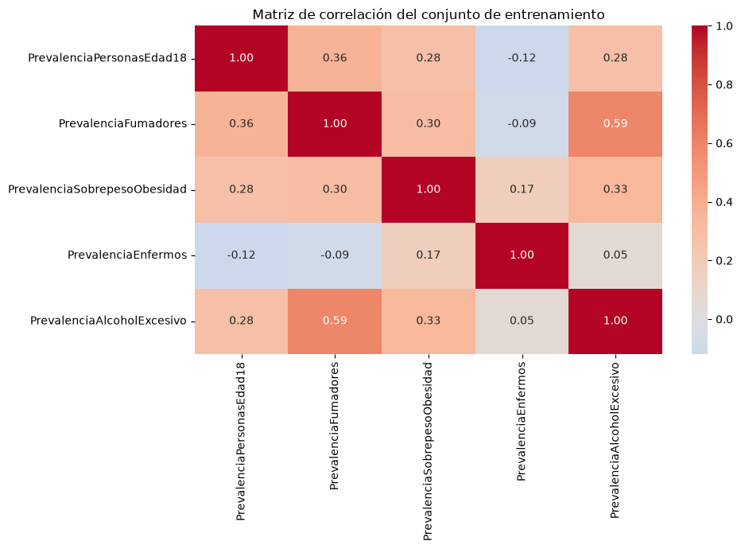

```python
variables_correlacion = variables_X + [variable_Y]

matriz_correlacion = train[variables_correlacion].corr()

plt.figure(figsize=(10, 7))
sns.heatmap(matriz_correlacion, annot=True,fmt=".2f",cmap="coolwarm",center=0)

plt.title("Matriz de correlación del conjunto de entrenamiento")
plt.tight_layout()
plt.show()
```

[GRÁFICA 1.] Matriz de correlación de las variables explicativas.

## Selección de características

Con el objetivo de conservar únicamente las variables que aportan información relevante para explicar el consumo excesivo de alcohol, se aplicaron dos métodos de selección de características: selección hacia adelante y selección hacia atrás. El propósito de estos métodos es reducir el número de variables y facilitar la interpretación del modelo. Para realizar estos métodos de selección, se utilizó un nivel de significancia de 0.05.

En la selección hacia adelante, la primera variable incorporada fue PrevalenciaFumadores, con un p-value de 0.0037. Al evaluar la incorporación de una segunda variable, ninguna presentó significancia estadística, por lo que el proceso se detuvo. Esto se observa en la Tabla 5.

Por otro lado, la selección hacia atrás comenzó considerando todas las variables y eliminó progresivamente aquellas con un p-value mayor a 0.05. Finalmente, este método también conservó únicamente PrevalenciaFumadores, con un p-value de 0.0037, esto es claramente representado en la Tabla 6.

En la Tabla 7, se observa que ambos métodos llegaron al mismo resultado, por lo que se seleccionó la prevalencia de fumadores como variable explicativa para la construcción de los modelos de regresión.

```python
def seleccion_adelante(data, variables_X, variable_Y, alpha=0.05):
    seleccionadas = []
    restantes = variables_X.copy()
    historial = []

    while len(restantes) > 0:
        resultados = []

        for variable in restantes:
            variables_prueba = seleccionadas + [variable]
            X = sm.add_constant(data[variables_prueba],has_constant="add")
            y = data[variable_Y]
            modelo = sm.OLS(y, X).fit()
            resultados.append({"Variable": variable,"p-value": modelo.pvalues[variable]})

        tabla_temporal = pd.DataFrame(resultados)
        mejor = tabla_temporal.loc[tabla_temporal["p-value"].idxmin()]
        mejor_variable = mejor["Variable"]
        mejor_p = mejor["p-value"]
        historial.append({"Variable evaluada": mejor_variable,"p-value": mejor_p})

        if mejor_p < alpha:
            seleccionadas.append(mejor_variable)
            restantes.remove(mejor_variable)
        else:
            break

    return seleccionadas, pd.DataFrame(historial)


variables_forward, historial_forward = seleccion_adelante(train,variables_X,variable_Y)

(historial_forward.style.hide(axis="index").format({"p-value": "{:.4f}"}).set_properties(**{'text-align': 'center'}).set_table_styles([{'selector': 'th', 'props': [('text-align', 'center')]}]).set_caption("[TABLA 5]. Selección de características hacia adelante."))
```

[TABLA 5]. Selección de características hacia adelante.

| Variable evaluada | p-value |
| --- | --- |
| PrevalenciaFumadores | 0.0037 |
| PrevalenciaSobrepesoObesidad | 0.4037 |

```python
def seleccion_atras(data, variables_X, variable_Y, alpha=0.05):
    seleccionadas = variables_X.copy()
    historial = []

    while len(seleccionadas) > 0:
        X = sm.add_constant(data[seleccionadas],has_constant="add")
        y = data[variable_Y]
        modelo = sm.OLS(y, X).fit()
        p_values = modelo.pvalues.drop("const")
        peor_variable = p_values.idxmax()
        peor_p = p_values.max()
        historial.append({"Variable evaluada": peor_variable,"p-value": peor_p})

        if peor_p > alpha:
            seleccionadas.remove(peor_variable)
        else:
            break

    return seleccionadas, pd.DataFrame(historial)


variables_backward, historial_backward = seleccion_atras(train,variables_X,variable_Y)
(historial_backward.style.hide(axis="index").format({"p-value": "{:.4f}"}).set_properties(**{'text-align': 'center'}).set_table_styles([{'selector': 'th', 'props': [('text-align', 'center')]}]).set_caption("[TABLA 6]. Selección de características hacia atrás."))
```

[TABLA 6]. Selección de características hacia atrás.

| Variable evaluada | p-value |
| --- | --- |
| PrevalenciaPersonasEdad18 | 0.7817 |
| PrevalenciaEnfermos | 0.6856 |
| PrevalenciaSobrepesoObesidad | 0.4037 |
| PrevalenciaFumadores | 0.0037 |

```python
comparacion_seleccion = pd.DataFrame({"Método": ["Selección hacia adelante","Selección hacia atrás"],"Variables seleccionadas": [", ".join(variables_forward) if variables_forward else "Ninguna",", ".join(variables_backward) if variables_backward else "Ninguna"],"Cantidad de variables": [len(variables_forward),len(variables_backward)]})
(comparacion_seleccion.style.hide(axis="index").set_properties(**{'text-align': 'center'}).set_table_styles([{'selector': 'th', 'props': [('text-align', 'center')]}]).set_caption("[TABLA 7]. Comparación de los métodos de selección paso a paso."))
```

[TABLA 7]. Comparación de los métodos de selección paso a paso.

| Método | Variables seleccionadas | Cantidad de variables |
| --- | --- | --- |
| Selección hacia adelante | PrevalenciaFumadores | 1 |
| Selección hacia atrás | PrevalenciaFumadores | 1 |

## Construcción del modelo lineal

A partir de las variables seleccionadas, se construyó un modelo de regresión lineal simple utilizando únicamente el conjunto de entrenamiento. El objetivo de este modelo es analizar la relación entre la variable seleccionada y la prevalencia de consumo excesivo de alcohol. Esto también tiene el propósito de establecer un modelo base para posteriormente compararlo con una alternativa no lineal.

En la Tabla 8, se pueden observar los coeficientes estimados de las variables, los p-values y otros estadísticos, cómo el error estándar y los intervalos de confianza. Los coeficientes estimados permiten conocer la magnitud de la relación de cada variable con la respuesta, mientras que los p-values permiten evaluar si dicha asociación es estadísticamente significativa.

El coeficiente obtenido para la prevalencia de fumadores fue de 0.7329, lo que indica una relación positiva con la prevalencia de consumo excesivo de alcohol. Debido a que ambas variables están expresadas como proporciones, un aumento de 1 punto porcentual en la prevalencia de fumadores se asocia con un aumento de aproximadamente 0.73 puntos porcentuales en la prevalencia de consumo excesivo de alcohol.

```python
X_train_modelo = sm.add_constant(train[variables_backward],has_constant="add")
X_test_modelo = sm.add_constant(test[variables_backward],has_constant="add")
y_train = train[variable_Y]
y_test = test[variable_Y]
modelo = sm.OLS(y_train,X_train_modelo).fit()

tabla_coeficientes = pd.DataFrame({"Variable": modelo.params.index,"Coeficiente": modelo.params.values,"Error estándar": modelo.bse.values,"Estadístico t": modelo.tvalues.values,"p-value": modelo.pvalues.values,"IC 95% inferior": modelo.conf_int()[0].values,"IC 95% superior": modelo.conf_int()[1].values})
(tabla_coeficientes.style.hide(axis="index").format({"Coeficiente": "{:.4f}","Error estándar": "{:.4f}","Estadístico t": "{:.4f}","p-value": "{:.4f}","IC 95% inferior": "{:.4f}","IC 95% superior": "{:.4f}"}).set_properties(**{"text-align": "center"}).set_table_styles([{"selector": "th","props": [("text-align", "center")]}]).set_caption("[TABLA 8]. Coeficientes y significancia estadística del modelo de regresión lineal simple con los datos de entrenamiento."))
```

[TABLA 8]. Coeficientes y significancia estadística del modelo de regresión lineal simple con los datos de entrenamiento.

| Variable | Coeficiente | Error estándar | Estadístico t | p-value | IC 95% inferior | IC 95% superior |
| --- | --- | --- | --- | --- | --- | --- |
| const | 0.2208 | 0.0409 | 5.3996 | 0.0000 | 0.1355 | 0.3061 |
| PrevalenciaFumadores | 0.7329 | 0.2235 | 3.2799 | 0.0037 | 0.2668 | 1.1991 |

### Evaluación del modelo lineal

De acuerdo con la Tabla 9, el modelo obtuvo un R² de 0.3498, lo que indica que la prevalencia de fumadores permite explicar aproximadamente el 35 % de la variabilidad observada en la prevalencia de consumo excesivo de alcohol dentro de los datos de entrenamiento. El R² ajustado fue de 0.3172, un valor cercano al R² original.

El modelo también presentó un estadístico F de 10.7578 con un p-value de 0.0037. Debido a que este valor es menor a 0.05, existe evidencia estadística de que el modelo de regresión es significativo, por lo que la relación encontrada entre la prevalencia de fumadores y el consumo excesivo de alcohol es relevante.

En cuanto al error de predicción, el modelo obtuvo un RMSE de entrenamiento de 0.0343, equivalente a aproximadamente 3.43 puntos porcentuales. Esto significa que las predicciones realizadas sobre los datos utilizados para construir el modelo presentan errores relativamente pequeños respecto a los valores reales.

```python
pred_train = modelo.predict(X_train_modelo)
rmse_train = np.sqrt(np.mean((y_train - pred_train)**2))
rss = np.sum((y_train - pred_train)**2)

tabla_modelo = pd.DataFrame({"R²": [modelo.rsquared],"R² ajustada": [modelo.rsquared_adj],"Estadístico F": [modelo.fvalue],"p-value F": [modelo.f_pvalue],"RSS": [rss],"RMSE Train": [rmse_train]})
(tabla_modelo.style.hide(axis="index").format({"R²": "{:.4f}","R² ajustada": "{:.4f}","Estadístico F": "{:.4f}","p-value F": "{:.4f}","RSS": "{:.4f}","RMSE Train": "{:.4f}"}).set_properties(**{"text-align": "center"}).set_table_styles([{"selector": "th","props": [("text-align", "center")]}]).set_caption("[TABLA 9]. Estadísticos generales del modelo de regresión lineal simple con datos de entrenamiento."))
```

[TABLA 9]. Estadísticos generales del modelo de regresión lineal simple con datos de entrenamiento.

| R² | R² ajustada | Estadístico F | p-value F | RSS | RMSE Train |
| --- | --- | --- | --- | --- | --- |
| 0.3498 | 0.3172 | 10.7578 | 0.0037 | 0.0259 | 0.0343 |

La Tabla 10 muestra que, al evaluar el modelo con datos de prueba, se obtuvo un R² de 0.4307, por lo que el modelo explicó aproximadamente el 43.1 % de la variabilidad de estas observaciones, mientras que el RMSE aumentó ligeramente de 3.43 a 4.12 puntos porcentuales.

En general, la diferencia entre los errores de entrenamiento y prueba es relativamente pequeña, por lo que no hay alguna indicación de un sobreajuste considerable. El modelo mantiene un comportamiento similar frente a observaciones que no fueron utilizadas durante su entrenamiento. Aunque todavía existe una proporción considerable de la variabilidad del consumo excesivo de alcohol que no es explicada únicamente por la prevalencia de tabaquismo.

```python
pred_test = modelo.predict(X_test_modelo)

r2_train = modelo.rsquared
r2_ajustado_train = modelo.rsquared_adj

ss_res_test = np.sum((y_test - pred_test)**2)
ss_tot_test = np.sum((y_test - y_test.mean())**2)
r2_test = 1 - (ss_res_test / ss_tot_test)

rmse_test = np.sqrt(np.mean((y_test - pred_test)**2))

mae_train = np.mean(np.abs(y_train - pred_train))

mae_test = np.mean(np.abs(y_test - pred_test))

tabla_desempeno = pd.DataFrame({"Modelo": ["Selección hacia atrás"],"R² Train": [r2_train],"R² ajustada Train": [r2_ajustado_train],"R² Test": [r2_test],"RMSE Train": [rmse_train],"RMSE Test": [rmse_test],"MAE Train": [mae_train],"MAE Test": [mae_test]})
(tabla_desempeno.style.hide(axis="index").format({"R² Train": "{:.4f}","R² ajustada Train": "{:.4f}","R² Test": "{:.4f}","RMSE Train": "{:.4f}","RMSE Test": "{:.4f}","MAE Train": "{:.4f}","MAE Test": "{:.4f}"}).set_properties(**{"text-align": "center"}).set_table_styles([{"selector": "th","props": [("text-align", "center")]}]).set_caption("[TABLA 10]. Comparación del desempeño del modelo de regresión lineal simple en datos de entrenamiento y prueba."))
```

[TABLA 10]. Comparación del desempeño del modelo de regresión lineal simple en datos de entrenamiento y prueba.

| Modelo | R² Train | R² ajustada Train | R² Test | RMSE Train | RMSE Test | MAE Train | MAE Test |
| --- | --- | --- | --- | --- | --- | --- | --- |
| Selección hacia atrás | 0.3498 | 0.3172 | 0.4307 | 0.0343 | 0.0412 | 0.0269 | 0.0337 |

La Gráfica 2 permite observar que los datos de entrenamiento y prueba siguen una tendencia similar alrededor de la recta de regresión. Aunque existe cierta dispersión entre las observaciones, no se aprecia un comportamiento completamente distinto entre ambos conjuntos.

También se observa que algunos estados se alejan más de la línea estimada, lo que indica que el modelo no logra explicar por completo todas las diferencias estatales. Esto sugiere que, además del tabaquismo, existen otros factores que podrían estar relacionados con el consumo excesivo de alcohol.

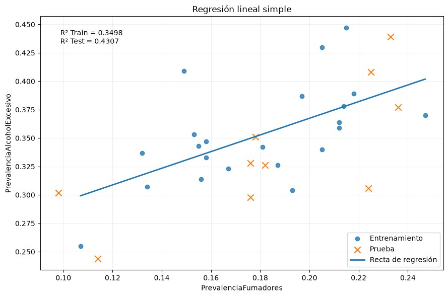

```python
variable_simple = variables_backward[0]

x_linea = np.linspace(train[variable_simple].min(),train[variable_simple].max(),200)
X_linea = pd.DataFrame({variable_simple: x_linea})
X_linea = sm.add_constant(X_linea,has_constant="add")
y_linea = modelo.predict(X_linea)

plt.figure(figsize=(9, 6))
plt.scatter(train[variable_simple],train[variable_Y],label="Entrenamiento",alpha=0.8)
plt.scatter(test[variable_simple],test[variable_Y],label="Prueba",marker="x",s=80)
plt.plot(x_linea,y_linea,linewidth=2,label="Recta de regresión")

plt.xlabel(variable_simple)
plt.ylabel(variable_Y)
plt.title("Regresión lineal simple")
plt.text(0.05,0.95,f"R² Train = {r2_train:.4f}\n"f"R² Test = {r2_test:.4f}",transform=plt.gca().transAxes,verticalalignment="top")

plt.legend()
plt.grid(alpha=0.2)
plt.tight_layout()
plt.show()
```

[GRÁFICA 2.] Recta de regresión lineal simple.

## Construcción del modelo no lineal

Para evaluar si la relación entre la prevalencia de fumadores y el consumo excesivo de alcohol podía representarse mejor mediante una relación no lineal, se construyó un modelo de regresión polinomial de grado 2.

Este tipo de modelo agrega un término cuadrático de la variable explicativa, permitiendo que la relación pueda presentar cierta curvatura en lugar de asumir que el cambio es completamente constante en todo el rango de los datos.

El modelo utilizado puede expresarse como: $$ \hat{Y} = \hat{\beta}_0 + \hat{\beta}_1 X + \hat{\beta}_2 X^2 $$

donde X corresponde a la prevalencia de fumadores y Y a la prevalencia estimada de consumo excesivo de alcohol.

El modelo fue ajustado utilizando el mismo conjunto de entrenamiento empleado en la regresión lineal y posteriormente evaluado con el mismo conjunto de prueba. De esta manera, ambos modelos pueden compararse bajo las mismas condiciones y determinar si la incorporación del término cuadrático representa una mejora real en la capacidad de explicar y predecir el consumo excesivo de alcohol.

La Tabla 11 muestra los coeficientes estimados para el modelo polinomial de grado 2. El término lineal de PrevalenciaFumadores obtuvo un coeficiente de 2.5950, mientras que el término cuadrático presentó un coeficiente de −5.2577. En conjunto, estos valores describen que el consumo excesivo de alcohol tiende inicialmente a aumentar conforme aumenta la prevalencia de fumadores, pero este crecimiento se va reduciendo en los valores más altos.

Sin embargo, los p-values del término lineal (0.2318) y del término cuadrático (0.3839) son mayores a 0.05, por lo que ninguno presenta significancia estadística de manera individual.

Por lo tanto, aunque el modelo de grado 2 permite representar una relación más flexible, no existe evidencia estadística suficiente para afirmar que el término cuadrático aporta una mejora significativa en la relación entre tabaquismo y consumo excesivo de alcohol.

```python
variable_simple = variables_backward[0]
X_train_modelo = pd.DataFrame({variable_simple: train[variable_simple],f"{variable_simple}^2": train[variable_simple]**2})
X_test_modelo = pd.DataFrame({variable_simple: test[variable_simple],f"{variable_simple}^2": test[variable_simple]**2})
X_train_modelo = sm.add_constant(X_train_modelo, has_constant="add")
X_test_modelo = sm.add_constant(X_test_modelo, has_constant="add")
y_train = train[variable_Y]
y_test = test[variable_Y]
modelo = sm.OLS(y_train, X_train_modelo).fit()

tabla_coeficientes = pd.DataFrame({"Variable": modelo.params.index,"Coeficiente": modelo.params.values,"Error estándar": modelo.bse.values,"Estadístico t": modelo.tvalues.values,"p-value": modelo.pvalues.values,"IC 95% inferior": modelo.conf_int()[0].values,"IC 95% superior": modelo.conf_int()[1].values})
(tabla_coeficientes.style.hide(axis="index").format({"Coeficiente": "{:.4f}","Error estándar": "{:.4f}","Estadístico t": "{:.4f}","p-value": "{:.4f}","IC 95% inferior": "{:.4f}","IC 95% superior": "{:.4f}"}).set_properties(**{"text-align": "center"}).set_table_styles([{"selector": "th", "props": [("text-align", "center")]}]).set_caption("[TABLA 11]. Coeficientes y significancia estadística del modelo de regresión polinomial de grado 2."))
```

[TABLA 11]. Coeficientes y significancia estadística del modelo de regresión polinomial de grado 2.

| Variable | Coeficiente | Error estándar | Estadístico t | p-value | IC 95% inferior | IC 95% superior |
| --- | --- | --- | --- | --- | --- | --- |
| const | 0.0622 | 0.1826 | 0.3405 | 0.7372 | -0.3201 | 0.4445 |
| PrevalenciaFumadores | 2.5950 | 2.1009 | 1.2351 | 0.2318 | -1.8024 | 6.9923 |
| PrevalenciaFumadores^2 | -5.2577 | 5.8983 | -0.8914 | 0.3839 | -17.6030 | 7.0876 |

### Evaluación del modelo no lineal

De acuerdo con la Tabla 12, el modelo polinomial de grado 2 obtuvo un R² de 0.3759, por lo que explica aproximadamente el 37.6 % de la variabilidad del consumo excesivo de alcohol en los datos de entrenamiento. Al considerar la complejidad adicional del modelo, el R² ajustado disminuye a 0.3102, lo que demuestra que incluir un polinomio de grado 2 no es la mejor alternativa.

El modelo en conjunto presenta un p-value F de 0.0114, menor a 0.05, por lo que puede considerarse estadísticamente significativo. Esto significa que, en conjunto, los términos incluidos aportan información para explicar la variable respuesta, aunque anteriormente se observó que los coeficientes individuales del término lineal y cuadrático no resultaron significativos. En cuanto al error, el RMSE de entrenamiento fue de 0.0336, equivalente aproximadamente a 3.36 puntos porcentuales.

```python
pred_train = modelo.predict(X_train_modelo)
rmse_train = np.sqrt(np.mean((y_train - pred_train)**2))
rss = np.sum((y_train - pred_train)**2)

tabla_modelo = pd.DataFrame({"R²": [modelo.rsquared],"R² ajustada": [modelo.rsquared_adj],"Estadístico F": [modelo.fvalue],"p-value F": [modelo.f_pvalue],"RSS": [rss],"RMSE Train": [rmse_train]})
(tabla_modelo.style.hide(axis="index").format({"R²": "{:.4f}","R² ajustada": "{:.4f}","Estadístico F": "{:.4f}","p-value F": "{:.4f}","RSS": "{:.4f}","RMSE Train": "{:.4f}"}).set_properties(**{"text-align": "center"}).set_table_styles([{"selector": "th", "props": [("text-align", "center")]}]).set_caption("[TABLA 12]. Estadísticos generales del modelo de regresión polinomial de grado 2."))
```

[TABLA 12]. Estadísticos generales del modelo de regresión polinomial de grado 2.

| R² | R² ajustada | Estadístico F | p-value F | RSS | RMSE Train |
| --- | --- | --- | --- | --- | --- |
| 0.3759 | 0.3102 | 5.7209 | 0.0114 | 0.0248 | 0.0336 |

La Tabla 13 muestra que el desempeño se mantiene relativamente estable en prueba, con un R² de 0.3851. Sin embargo, el RMSE aumenta a 4.28 puntos porcentuales. Esta diferencia indica una ligera pérdida de precisión al utilizar datos nuevos, aunque no se detectó un sobreajuste significativo.

En general, el modelo polinomial logra explicar parte de las diferencias estatales, pero la incorporación del término cuadrático no genera una mejora importante en el modelo predictivo.

```python
pred_test = modelo.predict(X_test_modelo)
r2_train = modelo.rsquared
r2_ajustado_train = modelo.rsquared_adj
ss_res_test = np.sum((y_test - pred_test)**2)
ss_tot_test = np.sum((y_test - y_test.mean())**2)
r2_test = 1 - (ss_res_test / ss_tot_test)
rmse_test = np.sqrt(np.mean((y_test - pred_test)**2))
mae_train = np.mean(np.abs(y_train - pred_train))
mae_test = np.mean(np.abs(y_test - pred_test))

tabla_desempeno = pd.DataFrame({"Modelo": ["Polinomio grado 2"],"R² Train": [r2_train],"R² ajustada Train": [r2_ajustado_train],"R² Test": [r2_test],"RMSE Train": [rmse_train],"RMSE Test": [rmse_test],"MAE Train": [mae_train],"MAE Test": [mae_test]})
(tabla_desempeno.style.hide(axis="index").format({"R² Train": "{:.4f}","R² ajustada Train": "{:.4f}","R² Test": "{:.4f}","RMSE Train": "{:.4f}","RMSE Test": "{:.4f}","MAE Train": "{:.4f}","MAE Test": "{:.4f}"}).set_properties(**{"text-align": "center"}).set_table_styles([{"selector": "th", "props": [("text-align", "center")]}]).set_caption("[TABLA 13]. Comparación del desempeño del modelo polinomial de grado 2 en entrenamiento y prueba."))
```

[TABLA 13]. Comparación del desempeño del modelo polinomial de grado 2 en entrenamiento y prueba.

| Modelo | R² Train | R² ajustada Train | R² Test | RMSE Train | RMSE Test | MAE Train | MAE Test |
| --- | --- | --- | --- | --- | --- | --- | --- |
| Polinomio grado 2 | 0.3759 | 0.3102 | 0.3851 | 0.0336 | 0.0428 | 0.0259 | 0.0373 |

La Gráfica 3 muestra que el modelo polinomial representa una relación creciente con cierta curvatura entre la prevalencia de fumadores y el consumo excesivo de alcohol. La curva aumenta con mayor rapidez en los valores bajos y medios de tabaquismo, pero comienza a aplanarse conforme aumenta la prevalencia de fumadores, lo cual coincide con el coeficiente negativo obtenido para el término cuadrático.

Las observaciones de entrenamiento y prueba presentan una dispersión considerable alrededor de la curva, especialmente en los niveles más altos de tabaquismo. Esto indica que la relación no sigue perfectamente una forma cuadrática y existen diferencias estatales que el modelo no alcanza a explicar.

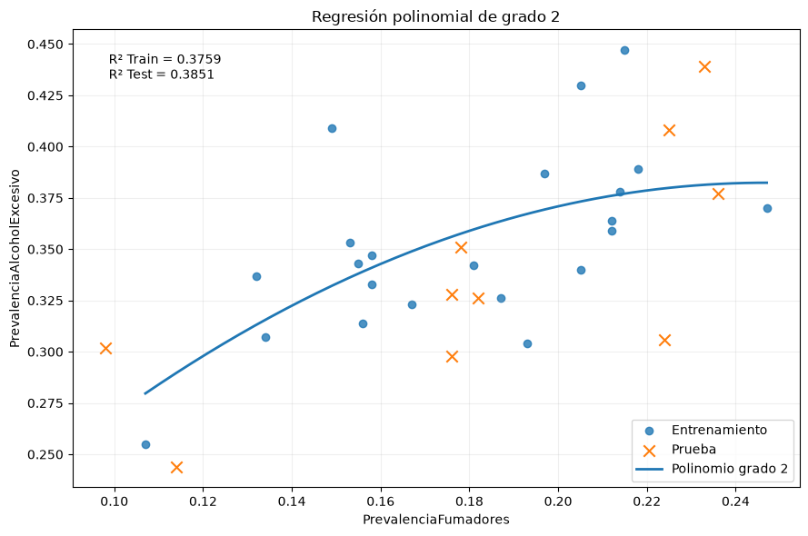

```python
x_linea = np.linspace(train[variable_simple].min(),train[variable_simple].max(),200)
X_linea = pd.DataFrame({variable_simple: x_linea,f"{variable_simple}^2": x_linea**2})
X_linea = sm.add_constant(X_linea,has_constant="add")
y_linea = modelo.predict(X_linea)

plt.figure(figsize=(9, 6))
plt.scatter(train[variable_simple],train[variable_Y],label="Entrenamiento",alpha=0.8)
plt.scatter(test[variable_simple],test[variable_Y],label="Prueba",marker="x",s=80)
plt.plot(x_linea,y_linea,linewidth=2,label="Polinomio grado 2")
plt.xlabel(variable_simple)
plt.ylabel(variable_Y)
plt.title("Regresión polinomial de grado 2")
plt.text(0.05,0.95,f"R² Train = {r2_train:.4f}\n"f"R² Test = {r2_test:.4f}",transform=plt.gca().transAxes,verticalalignment="top")
plt.legend()
plt.grid(alpha=0.2)
plt.tight_layout()
plt.show()
```

[GRÁFICA 3.] Curva de regresión polinomial de grado 2.

## Comparación de los modelos

La Tabla 14 muestra que el modelo de grado 2 presenta una ligera mejora en algunas métricas de entrenamiento. Su R^2 aumenta de 0.3498 a 0.3759, mientras que el RSS disminuye de 0.0259 a 0.0248 y el RMSE de 0.0343 a 0.0336. Al considerar el R^2 ajustado, el modelo de grado 1 obtiene un valor ligeramente mayor, 0.3172, que el modelo de grado 2, 0.3102. Esto indica que el modelo de segundo grado no aporta una mejora suficiente.

Aunque el modelo de grado 2 es estadísticamente significativo en conjunto (p-value F = 0.0114), la comparación directa con el modelo lineal produjo un F de 0.7946 y un p-value de 0.3839. Debido a que este último valor es mayor a 0.05, la incorporación del término cuadrático no produce una mejora estadísticamente significativa respecto al modelo de grado 1. Por lo tanto, no existe evidencia suficiente para justificar el aumento de complejidad del modelo.

Por lo tanto, aunque el modelo de grado 2 reduce ligeramente el error de entrenamiento y aumenta el R^2, estas mejoras no son estadísticamente significativas. Por su mayor simplicidad, facilidad de interpretación y desempeño similar, se considera que el modelo de grado 1 es la opción más adecuada para este análisis.

```python
pred_train_g1 = modelo_g1.predict(X_train_g1)
pred_train_g2 = modelo_g2.predict(X_train_g2)

rss_g1 = np.sum((y_train - pred_train_g1)**2)
rss_g2 = np.sum((y_train - pred_train_g2)**2)

rmse_g1 = np.sqrt(np.mean((y_train - pred_train_g1)**2))
rmse_g2 = np.sqrt(np.mean((y_train - pred_train_g2)**2))

f_comparacion, p_comparacion, diferencia_gl = modelo_g2.compare_f_test(modelo_g1)
p_cuadratico = modelo_g2.pvalues[f"{variable_simple}^2"]

tabla_comparacion = pd.DataFrame({"Modelo": ["Grado 1","Grado 2"],"R²": [modelo_g1.rsquared,modelo_g2.rsquared],
    "R² ajustada": [modelo_g1.rsquared_adj,modelo_g2.rsquared_adj],
    "Estadístico F": [modelo_g1.fvalue,modelo_g2.fvalue],
    "p-value F": [modelo_g1.f_pvalue,modelo_g2.f_pvalue],
    "RSS": [rss_g1,rss_g2],
    "RMSE": [rmse_g1,rmse_g2],
    "p-value X²": [np.nan,p_cuadratico],
    "F comparación": [np.nan,f_comparacion],
    "p-value comparación": [np.nan,p_comparacion]})


(tabla_comparacion.style
    .hide(axis="index")
    .format({
        "R²": "{:.4f}",
        "R² ajustada": "{:.4f}",
        "Estadístico F": "{:.4f}",
        "p-value F": "{:.4f}",
        "RSS": "{:.4f}",
        "RMSE": "{:.4f}",
        "p-value X²": "{:.4f}",
        "F comparación": "{:.4f}",
        "p-value comparación": "{:.4f}"}, na_rep="-").set_properties(**{"text-align": "center"}).set_table_styles([{"selector": "th","props": [("text-align", "center")]}]).set_caption("[TABLA 14]. Comparación estadística entre los modelos de grado 1 y grado 2."))
```

[TABLA 14]. Comparación estadística entre los modelos de grado 1 y grado 2.

| Modelo | R² | R² ajustada | Estadístico F | p-value F | RSS | RMSE | p-value X² | F comparación | p-value comparación |
| --- | --- | --- | --- | --- | --- | --- | --- | --- | --- |
| Grado 1 | 0.3498 | 0.3172 | 10.7578 | 0.0037 | 0.0259 | 0.0343 | - | - | - |
| Grado 2 | 0.3759 | 0.3102 | 5.7209 | 0.0114 | 0.0248 | 0.0336 | 0.3839 | 0.7946 | 0.3839 |

### Selección del modelo final

A partir de la comparación realizada, se seleccionó el modelo lineal de grado 1 como modelo final. Aunque el modelo polinomial de grado 2 presentó una ligera mejora en algunas métricas de entrenamiento, esta mejora no fue estadísticamente significativa y tampoco representó una ventaja clara en los datos de prueba.

Por esta razón, se decidió conservar el modelo lineal, ya que ofrece un desempeño similar con una estructura más sencilla y una interpretación más clara.

## Análisis de inferencia

Para la prevalencia de fumadores se obtuvo un coeficiente de 0.7329, con un p-value de 0.0037, menor al nivel de significancia de 0.05. Por lo tanto, existe evidencia estadística de una asociación positiva entre el tabaquismo y el consumo excesivo de alcohol. En términos prácticos, un aumento de 1 punto porcentual en la prevalencia de fumadores se asocia con un aumento de aproximadamente 0.73 puntos porcentuales en la prevalencia de consumo excesivo de alcohol.

Además, el intervalo de confianza del 95 % para este coeficiente se encuentra entre 0.2668 y 1.1991. Como este intervalo no incluye el cero, se refuerza la evidencia de que la asociación encontrada es positiva y estadísticamente significativa.

## Conclusiones

El objetivo de este proyecto fue analizar en qué medida la prevalencia de tabaquismo, la estructura de edad, la prevalencia de sobrepeso u obesidad y la prevalencia de enfermos permiten explicar las diferencias estatales en el consumo excesivo de alcohol en México.

Los métodos de selección de características hacia adelante y hacia atrás coincidieron en conservar únicamente la prevalencia de fumadores. Las demás variables no mostraron evidencia estadística suficiente para mantenerse dentro del modelo final. Para el tabaquismo se obtuvo un coeficiente de 0.7329 y un p-value de 0.0037, lo que indica que un aumento de un punto porcentual en la prevalencia de fumadores se asocia, en promedio, con un incremento aproximado de 0.73 puntos porcentuales en el consumo excesivo de alcohol.

Al comparar los modelos, el modelo lineal presentó un RMSE de prueba de aproximadamente 4.12 puntos porcentuales, mientras que el modelo polinomial de grado 2 obtuvo aproximadamente 4.28 puntos porcentuales. Estos valores pueden utilizarse como referencia del error esperado de las predicciones. Además, la incorporación del término cuadrático no produjo una mejora estadísticamente significativa (p=0.3839), por lo que se seleccionó el modelo lineal por su menor complejidad y mejor interpretación.

Por lo tanto, la pregunta de investigación se responde de manera parcial. Los resultados no respaldan que las cuatro variables expliquen conjuntamente las diferencias estatales en el consumo excesivo de alcohol. Dentro de los datos analizados, únicamente el tabaquismo presentó una asociación estadísticamente significativa.

Entre las principales limitaciones se encuentra el reducido tamaño de la muestra, ya que únicamente se dispone de las 32 entidades federativas, además de trabajar con datos agregados a nivel estatal. Por esta razón, los resultados describen asociaciones entre características de los estados y no necesariamente el comportamiento individual de sus habitantes. Asimismo, las asociaciones encontradas no implican causalidad y pueden existir variables relevantes que no fueron consideradas en el estudio.

Como trabajo futuro, sería conveniente incorporar variables socioeconómicas y culturales, como ingreso, escolaridad, urbanización, disponibilidad de alcohol, percepción social del consumo o características de las prácticas de convivencia. También sería útil analizar información de varios años para aumentar el número de observaciones y estudiar si las relaciones encontradas se mantienen a través del tiempo. Esto permitiría desarrollar un modelo más completo del consumo excesivo de alcohol y comprender mejor las diferencias existentes entre las entidades de México.

## Bibliografía

Barrera-Núñez, D. A., Sánchez-Pájaro, A., Ramírez-Toscano, Y., Muciño-Sandoval, K., Reynales-Shigematsu, L. M., Colchero, M. A., Barrientos-Gutiérrez, T., & López-Olmedo, N. (2025). Consumo de alcohol en población adolescente y adulta mexicana: Análisis subnacional, Ensanut 2020-2024. Salud Pública de México, 67(6), 757–766. https://doi.org/10.21149/16994

Comisión Nacional de Salud Mental y Adicciones. (2024, 15 de noviembre). Secretaría de Salud promueve el autocuidado y la prevención frente al consumo de bebidas alcohólicas. Gobierno de México. https://www.gob.mx/conasama/articulos/secretaria-de-salud-promueve-el-autocuidado-y-la-prevencion-frente-al-consumo-de-bebidas-alcoholicas

Instituto Nacional de Estadística y Geografía [INEGI]. (2026, 28 de agosto). Tabulados interactivos de población. https://www.inegi.org.mx/app/tabulados/interactivos/?pxq=Poblacion_Poblacion_01_e60cd8cf-927f-4b94-823e-972457a12d4b

Secretaría de Salud, Dirección General de Epidemiología. (2026, 28 de agosto). Morbilidad estatal. Anuario de Morbilidad 1984–2025. https://epidemiologia.salud.gob.mx/anuario/html/morbilidad_estatal.html

Shamah-Levy, T., Romero-Martínez, M., Cuevas-Nasu, L., Gaona-Pineda, E. B., Muñoz-Espinosa, A., Hernández-Palafox, C., & Ávila-Arcos, M. A. (2025). Resultados estatales de la Encuesta Nacional de Salud y Nutrición Continua 2020-2024. Salud Pública de México, 67(Supl. 1), S3–S219. https://doi.org/10.21149/17642